# Crypto Currency Analysis Report PT1

[figure not shown]

[figure not shown]

[figure not shown]

[figure not shown]

# About This Report

**About This HTML File**

This **R HTML Document** goes over the steps I’ve taken to analyze a particular security. This notebook will be updated periodically with new information and scripts and should be considered as a `work in progress`.

### R Packages Used

Load appropriate packages needed to pull and format the data:

```
[1] "reshape2 PerformanceAnalytics PortfolioAnalytics quantmod ggplot2 ggthemes forecast tseries plotly astsa highcharter"
```

**Note:** This HTML file is mainly to outline my skill with the R Statiscal Programming language and is prepared solely for informational purposes, and is not an offer to buy or sell or a solicitation of an offer to buy or sell any security, product, service or investment. The opinions expressed in this HTML file do not constitute investment advice and independent advice should be sought where appropriate.

# Target Asset

There are several components to note in the interactive chart below.

### Target Asset

[interactive chart not shown]

Stock Price Trend of the Target Security

# Stationarity

The charts below shows the time series data of the adjusted price in the top most graph with the corresponding ACF and PACF plots below. An obvious upward trend would indicate a probable change in mean and variance over time. Any trend in the data will make it non-stationary. `Differencing` is a transformation method used to stabalize the variance of a time series. The ACF plot is also useful for identifying non-stationary time series. For a stationary time series, the ACF will drop to zero relatively quickly, while the ACF of non-stationary data decreases slowly.

### Test for Stationarity on BTC-USD

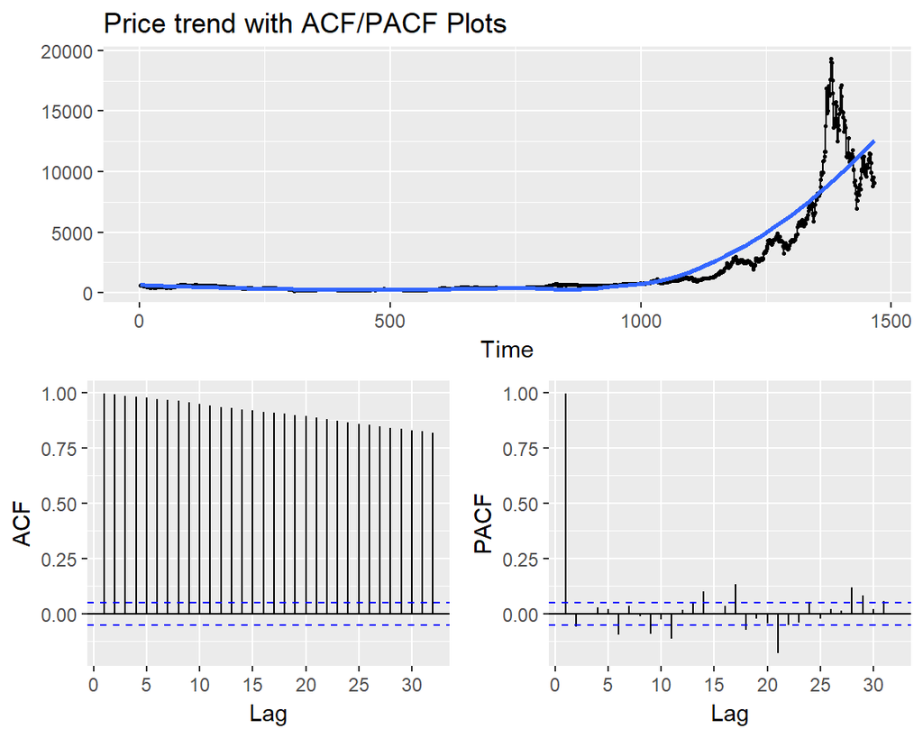

# First Order Diff

### Differencing the Data

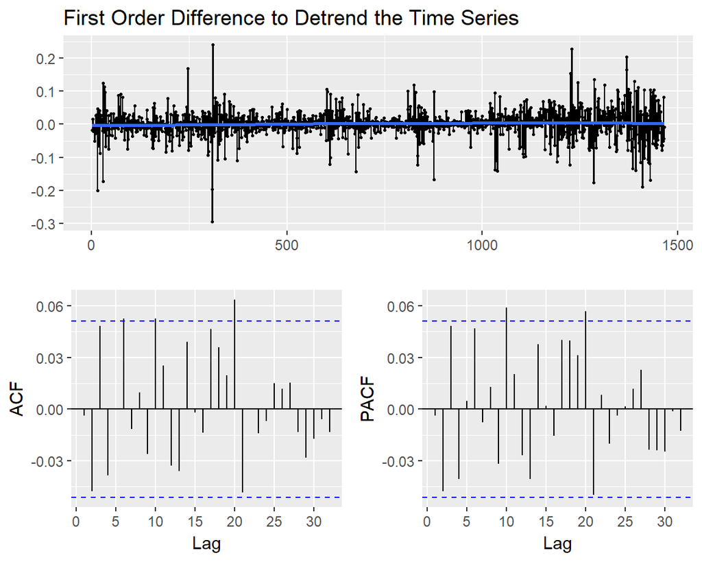

# TS Components

The key parts of the time series to investigate are it’s `trend` and `seasonal` components.

Daily vaules were converted into **monthly periodicity** to reduce variability and to better extract the time series components.

A summary of the values for each season.

### Time Series Components

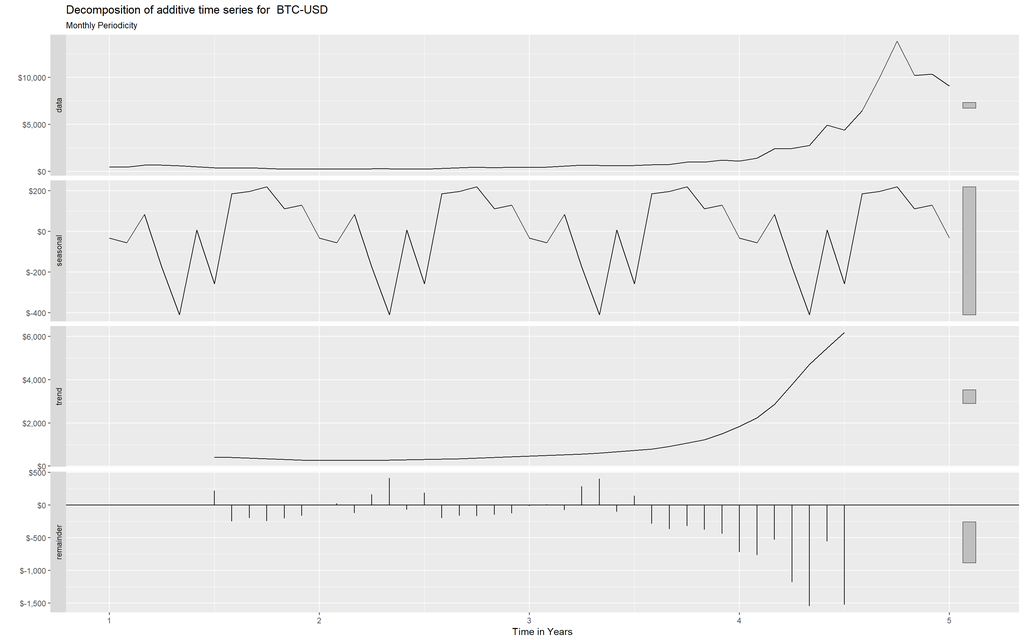

### Seasonal Values

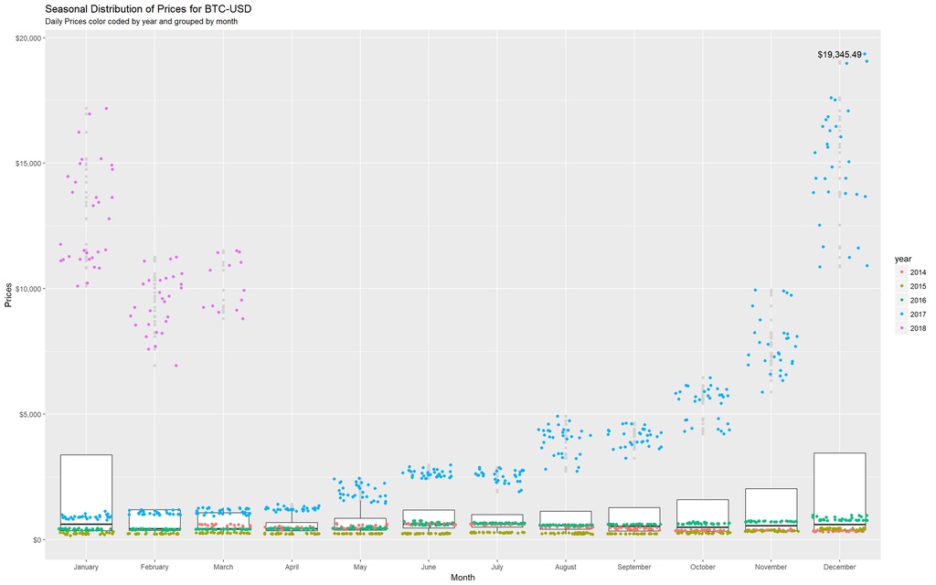

### Ljung-Box Test

The p-value of the `Ljung-Box` test below 0.05 suggest that the series is non-stationary.

```
    Box-Ljung test

data:  ts_daily
X-squared = 30975, df = 24, p-value < 2.2e-16
```

````r
---
title: "Crypto Currency Analysis Report PT1"
author: "by Courtney Williams"
output:
  flexdashboard::flex_dashboard:
    orientation: rows
    vertical_layout: fill
    source_code: embed
---

```{r setup, include=FALSE}
Sys.setlocale("LC_ALL","English")
library(flexdashboard)
```



About This Report
=======================================================================


Sidebar {.sidebar}
-----------------------------------------------------------------------

***

**About This HTML File**

This **R HTML Document** goes over the steps I've taken to analyze a particular security. This notebook will be updated periodically with new information and scripts and should be considered as a `work in progress`.


Column
-----------------------------------------------------------------------


### R Packages  Used

Load appropriate packages needed to pull and format the data:

```{r}
paste(
"reshape2",
"PerformanceAnalytics",
"PortfolioAnalytics",
"quantmod",
"ggplot2",
"ggthemes",
"forecast",
"tseries",
"plotly",
"astsa",
"highcharter"
)
```


**Note:**
This HTML file is mainly to outline my skill with the R Statiscal Programming language and is prepared solely for informational purposes, and is not an offer to buy or sell or a solicitation of an offer to buy or sell any security, product, service or investment. The opinions expressed in this HTML file do not constitute investment advice and independent advice should be sought where appropriate.

```{r}
# Load appropriate packages needed to pull and format the data
require(reshape2)
library(PerformanceAnalytics)
library(PortfolioAnalytics)
library(quantmod)
library(ggplot2)
library(ggthemes)
library(scales)
library(forecast)
library(tseries)
library(plotly)
library(astsa)
library(highcharter)
```




Target Asset {data-navmenu="Analysis" data-icon="fa-line-chart"}
=====================================================================

Sidebar {.sidebar}
-------------------------------------------------------

***

There are several components to note in the interactive chart below.

1. The first section shows the OHLC prices
2. The second section outlines trading activity as volume of shares for that day
3. The third section is the Williams Percent Range, a momentum indicator that measures overbought and oversold levels - over the red line is overbought [time to sell] and below the blue is over sold [time to buy].
4. This is just a range selctor toggle with the time period.



Row
-----------------------------------------------------------------------


### Target Asset


```{r echo=FALSE,error=FALSE,message=FALSE,warning=FALSE,fig.cap="Stock Price Trend of the Target Security"}
# pull stock
symbol = c("BTC-USD")
target <- getSymbols(symbol, from = Sys.Date() - lubridate::years(4), auto.assign = FALSE)
target <- adjustOHLC(target, adjust = c("split","dividend"), symbol.name = symbol)

colnames(target) = c("Open","High","Low","Close","Volume","Adjusted")

target.SMA.10 <- SMA(Cl(target), n = 5)
target.SMA.200 <- SMA(Cl(target), n = 100)
target.RSI.2 <- RSI(Cl(target), n = 2)
target.RSI.SellLevel <- xts(rep(70, NROW(target)), index(target))
target.RSI.BuyLevel <- xts(rep(30, NROW(target)), index(target))


highchart(type = "stock") %>%
  # create axis :)
  hc_yAxis_multiples(
    create_yaxis(3, height = c(2, 1, 1), turnopposite = TRUE)
  ) %>%
  # series :D
  hc_add_series(target, yAxis = 0, name = paste(symbol)) %>%
  #hc_add_series(target.SMA.10, yAxis = 0, name = "Fast MA") %>%
  #hc_add_series(target.SMA.200, yAxis = 0, name = "Slow MA") %>%
  hc_add_series(target$Volume, color = "gray", yAxis = 1, name = "Volume", type = "column") %>%
  hc_add_series(target.RSI.2, yAxis = 2, name = "Osciallator", color = hex_to_rgba("green", 0.7)) %>%
  hc_add_series(target.RSI.SellLevel, color = hex_to_rgba("red", 0.7),
                yAxis = 2, name = "Sell level") %>%
  hc_add_series(target.RSI.BuyLevel, color = hex_to_rgba("blue", 0.7),
                yAxis = 2, name = "Buy level")
  # hc_add_theme(hc_theme_538()) %>%
  # hc_title(text = paste(target, "Stock Price over time")) %>% hc_subtitle(text = "Graph plotted using the highcharter package")
```


Stationarity {data-navmenu="Analysis" data-icon="fa-dashboard"}
=====================================================================


Sidebar {.sidebar}
-----------------------------------------------------------

***

The charts below shows the time series data of the adjusted price in the top most graph with the corresponding ACF and PACF plots below. An obvious upward trend would indicate a probable change in mean and variance over time. Any trend in the data will make it non-stationary. `Differencing` is a transformation method used to stabalize the variance of a time series. The ACF plot is also useful for identifying non-stationary time series. For a stationary time series, the ACF will drop to zero relatively quickly, while the ACF of non-stationary data decreases slowly.


Row
-----------------------------------------------------------------------


### Test for Stationarity on `r symbol`


```{r echo=FALSE,error=FALSE,message=FALSE,warning=FALSE}
# pull adjusted price
target_Adjusted = Ad(target)
colnames(target_Adjusted) = "Adjusted"

# make irregular time series data regular

# create a date sequence
date_seq = seq(from = start(target_Adjusted),
                to = end(target_Adjusted),
                by = "day")

regular_xts = xts(, date_seq)

# merge the two objects into one xts object and carry the last observation forward
merge_xts = merge(target_Adjusted,regular_xts, fill = na.locf)


# identify the process
#x = acf2(merge_xts, max.lag = 60)

ggtsdisplay(merge_xts, main = "Price trend with ACF/PACF Plots", smooth = TRUE, xlab = "Time")
```







First Order Diff {data-navmenu="Analysis"}
=====================================================================


Sidebar {.sidebar}
--------------------------------------------------------------

***

The first order differenced time series should show a more stationary looking time series. Both the `ACF` and `PACF` plot should tail off to zero characteristics of non-stationarity.


Row
-----------------------------------------------------------------------



### Differencing the Data



```{r error=FALSE,message=FALSE,warning=FALSE}
merge_xts_diff = diff(log(merge_xts))

ggtsdisplay(merge_xts_diff, main = "First Order Difference to Detrend the Time Series", smooth = TRUE)
```




TS Components {data-navmenu="Analysis" data-icon="fa-list"}
=====================================================================


Sidebar {.sidebar}
---------------------------------------------------

***

The key parts of the time series to investigate are it's `trend` and `seasonal` components.

Daily vaules were converted into **monthly periodicity** to reduce variability and to better extract the time series components.


***

A summary of the values for each season.


Column {.tabset .tabset-fade}
-----------------------------------------------------------------------

### Time Series Components


```{r error=FALSE,message=FALSE,warning=FALSE, fig.width=16, fig.height=10}
# convet from daily to monthly periodocity
monthlydata = to.period(merge_xts, period = "months", OHLC = FALSE)

# convert ts object
ts_object = ts(monthlydata, frequency = 12)

# plot components of time series
trend = autoplot(decompose(ts_object))+
  scale_y_continuous(labels = dollar) +
  ggtitle(paste("Decomposition of additive time series for ",symbol), subtitle = "Monthly Periodicity")+
  xlab("Time in Years")

trend

```


### Seasonal Values



```{r error=FALSE,message=FALSE,warning=FALSE, fig.width=16, fig.height=10}
#boxplot(ts_object ~ cycle(ts_object), xlab='Month')

xts_df = data.frame(date=index(merge_xts), coredata(merge_xts))

xts_df['date2'] = format(xts_df$date,'%B')
xts_df$sort = as.POSIXlt(xts_df$date)$mon
xts_df$year = format(xts_df$date,'%Y')


ggplot(xts_df, aes(x=reorder(date2,sort),y=Adjusted)) +
  geom_boxplot(outlier.color = 'light grey') + geom_jitter(aes(fill=year, color=year)) +
  xlab("Month") + ylab("Prices") + scale_y_continuous(labels = dollar) +
  geom_text(aes(label=ifelse(Adjusted==max(Adjusted),dollar(Adjusted),'')))+
  ggtitle(paste("Seasonal Distribution of Prices for",symbol), subtitle = "Daily Prices color coded by year and grouped by month")


```



### Ljung-Box Test

The p-value of the `Ljung-Box` test below 0.05 suggest that the series is non-stationary.


```{r error=FALSE,message=FALSE,warning=FALSE}
# conveert xts to ts with frequency of 360 elements per cycle
ts_daily = ts(merge_xts, frequency = 360)

# perform Ljung-Box test time series
Box.test(ts_daily, lag = 24, fitdf = 0, type = "Lj")
```
````